# Bank-Marketing

*Authors*: [Mauro Venticinque](https://it.linkedin.com/in/mauro-venticinque-01a297212) | [Angelo Schillaci](https://www.linkedin.com/in/angelo-schillaci-095064213) | [Daniele Tambone](https://www.linkedin.com/in/daniele-tambone-b5733616a)

*GitHub project*: Bank-Marketing

*Date*: 2025-05-19

## 1 Introduction

In this project, we analyze data from a Portuguese banking institution’s direct marketing campaigns to identify key factors influencing customer subscription to term deposits.

The dataset includes client demographics, previous campaign interactions, and economic indicators. Our goal is to develop insights that will enhance the effectiveness of future marketing strategies. By applying supervised learning techniques, we aim to predict customer responses and optimize outreach efforts for better engagement and conversion rates.

## 2 Model selection

### 2.1 Preprocessing

Based on the Exploratory Data Analysis (EDA), we selected only the most relevant variables.

With a view to training the model, we apply **one-hot encoding**. We obtain the following dataset:

21 Variable

| Variable | Type |
| --- | --- |
| age | int |
| single | bool |
| cellular | bool |
| low_call | bool |
| previous | int |
| negative_emp | bool |
| low_cpi | bool |
| high_cci | bool |
| low_euribor | bool |
| university | bool |
| p_course | bool |
| job_student | bool |
| job_retired | bool |
| job_admin | bool |
| month_sep | bool |
| month_oct | bool |
| month_dec | bool |
| month_mar | bool |
| p_failure | bool |
| p_success | bool |
| target | bool |

### 2.2 STEPWISE selection

```r
full_model <- glm(target ~ ., data = full_df, family = binomial)
stepwise <- stepAIC(full_model, direction = "both", trace = FALSE)
vif(stepwise)
```

```
##       single     cellular     low_call     previous negative_emp      low_cpi
##     1.161049     1.257740     1.015602     4.030389     4.797421     1.673660
##     high_cci  low_euribor   university     p_course  job_student  job_retired
##     1.356434     5.001553     1.257091     1.123516     1.172201     1.114729
##    job_admin    month_sep    month_oct    month_dec    month_mar    p_failure
##     1.209488     1.109976     1.074431     1.051192     1.039553     2.885715
##    p_success
##     2.653624
```

```r
# predictore removed by Stepwise
stepwise$anova
```

```
## Stepwise Model Path
## Analysis of Deviance Table
##
## Initial Model:
## target ~ age + single + cellular + low_call + previous + negative_emp +
##     low_cpi + high_cci + low_euribor + university + p_course +
##     job_student + job_retired + job_admin + month_sep + month_oct +
##     month_dec + month_mar + p_failure + p_success
##
## Final Model:
## target ~ single + cellular + low_call + previous + negative_emp +
##     low_cpi + high_cci + low_euribor + university + p_course +
##     job_student + job_retired + job_admin + month_sep + month_oct +
##     month_dec + month_mar + p_failure + p_success
##
##
##    Step Df    Deviance Resid. Df Resid. Dev      AIC
## 1                          32929   18541.01 18583.01
## 2 - age  1 0.009056746     32930   18541.02 18581.02
```

```r
stepwise_formula <- target ~ single + cellular + low_call + previous + negative_emp +
  low_cpi + high_cci + low_euribor + university + p_course +
  job_student + job_retired + job_admin + month_sep + month_oct +
  month_dec + month_mar + p_failure + p_success
```

### 2.3 LASSO selection

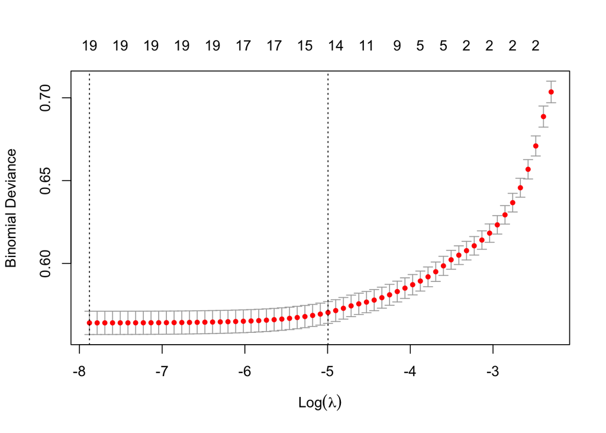

```r
set.seed(123)

df_no_target <- subset(full_df, select = -target)

fit_lasso <- glmnet(x = as.matrix(df_no_target),
                    y = target,
                    alpha = 1,
                    family = "binomial",
)

cv_fit <- cv.glmnet(
  x = as.matrix(df_no_target),
  y = target,
  alpha = 1,
  family = "binomial"
)

plot(cv_fit)
```

```r
# predictors selected by Lasso
coef(cv_fit, s = "lambda.1se")
```

```
## 21 x 1 sparse Matrix of class "dgCMatrix"
##                       s1
## (Intercept)  -3.40260756
## age           .
## single        .
## cellular      0.26429155
## low_call      .
## previous      .
## negative_emp  0.33148264
## low_cpi      -0.15716970
## high_cci      0.54539233
## low_euribor   1.22932991
## university    0.02599663
## p_course      .
## job_student   0.27874368
## job_retired   0.29253325
## job_admin     .
## month_sep     0.25751717
## month_oct     0.59082454
## month_dec     0.28825879
## month_mar     0.96303668
## p_failure    -0.12024151
## p_success     1.54745367
```

```r
lasso_formula <- target ~ cellular + negative_emp +
  low_cpi + high_cci + low_euribor + university +
  job_student + job_retired + month_sep + month_oct +
  month_dec + month_mar + p_failure + p_success

lasso_mod<-glm(lasso_formula, data=full_df, family=binomial)
```

### 2.4 Comperison

```r
summary(stepwise)
```

```
##
## Call:
## glm(formula = target ~ single + cellular + low_call + previous +
##     negative_emp + low_cpi + high_cci + low_euribor + university +
##     p_course + job_student + job_retired + job_admin + month_sep +
##     month_oct + month_dec + month_mar + p_failure + p_success,
##     family = binomial, data = full_df)
##
## Coefficients:
##              Estimate Std. Error z value Pr(>|z|)
## (Intercept)  -4.12030    0.10037 -41.052  < 2e-16 ***
## single        0.08955    0.04463   2.007  0.04477 *
## cellular      0.48749    0.05437   8.966  < 2e-16 ***
## low_call      0.28095    0.09007   3.119  0.00181 **
## previous      0.11396    0.05858   1.946  0.05171 .
## negative_emp  0.54235    0.09230   5.876 4.20e-09 ***
## low_cpi      -0.55291    0.05180 -10.674  < 2e-16 ***
## high_cci      0.70524    0.04530  15.568  < 2e-16 ***
## low_euribor   1.40709    0.09007  15.622  < 2e-16 ***
## university    0.13424    0.04578   2.932  0.00336 **
## p_course      0.10243    0.06164   1.662  0.09655 .
## job_student   0.48616    0.10267   4.735 2.19e-06 ***
## job_retired   0.52247    0.07832   6.671 2.54e-11 ***
## job_admin     0.10922    0.04752   2.298  0.02153 *
## month_sep     0.32774    0.10954   2.992  0.00277 **
## month_oct     0.77146    0.09676   7.973 1.55e-15 ***
## month_dec     0.79355    0.18087   4.387 1.15e-05 ***
## month_mar     1.12505    0.10898  10.323  < 2e-16 ***
## p_failure    -0.58715    0.09471  -6.199 5.67e-10 ***
## p_success     1.26651    0.11283  11.225  < 2e-16 ***
## ---
## Signif. codes:  0 '***' 0.001 '**' 0.01 '*' 0.05 '.' 0.1 ' ' 1
##
## (Dispersion parameter for binomial family taken to be 1)
##
##     Null deviance: 23199  on 32949  degrees of freedom
## Residual deviance: 18541  on 32930  degrees of freedom
## AIC: 18581
##
## Number of Fisher Scoring iterations: 6
```

```r
summary(lasso_mod)
```

```
##
## Call:
## glm(formula = lasso_formula, family = binomial, data = full_df)
##
## Coefficients:
##              Estimate Std. Error z value Pr(>|z|)
## (Intercept)  -3.82821    0.05730 -66.814  < 2e-16 ***
## cellular      0.50192    0.05423   9.255  < 2e-16 ***
## negative_emp  0.56272    0.09214   6.108 1.01e-09 ***
## low_cpi      -0.57685    0.05098 -11.314  < 2e-16 ***
## high_cci      0.73139    0.04488  16.296  < 2e-16 ***
## low_euribor   1.42629    0.08966  15.907  < 2e-16 ***
## university    0.15292    0.04187   3.652  0.00026 ***
## job_student   0.50976    0.09664   5.275 1.33e-07 ***
## job_retired   0.46140    0.07643   6.037 1.57e-09 ***
## month_sep     0.33778    0.10917   3.094  0.00197 **
## month_oct     0.78992    0.09678   8.162 3.30e-16 ***
## month_dec     0.77731    0.18053   4.306 1.66e-05 ***
## month_mar     1.14224    0.10900  10.479  < 2e-16 ***
## p_failure    -0.44660    0.05939  -7.519 5.51e-14 ***
## p_success     1.43643    0.07412  19.379  < 2e-16 ***
## ---
## Signif. codes:  0 '***' 0.001 '**' 0.01 '*' 0.05 '.' 0.1 ' ' 1
##
## (Dispersion parameter for binomial family taken to be 1)
##
##     Null deviance: 23199  on 32949  degrees of freedom
## Residual deviance: 18567  on 32935  degrees of freedom
## AIC: 18597
##
## Number of Fisher Scoring iterations: 6
```

```r
# Compare the models
stepwise_results <- k_fold_mod(data = full_df, target_col = "target", model_formula = stepwise)
lasso_results    <- k_fold_mod(data = full_df, target_col = "target", model_formula = lasso_mod)
print(stepwise_results)
```

```
## $Accuracy_at_best_threshold
## [1] "0.8991 (threshold = 0.53)"
##
## $F1_at_best_threshold
## [1] "0.4832 (threshold = 0.22)"
##
## $Sensitivity
## [1] 0.538
##
## $Specificity
## [1] 0.9127
##
## $AUC
## [1] 0.7811
##
## $AIC
## [1] 16724.85
```

```r
print(lasso_results)
```

```
## $Accuracy_at_best_threshold
## [1] "0.899 (threshold = 0.5)"
##
## $F1_at_best_threshold
## [1] "0.4855 (threshold = 0.21)"
##
## $Sensitivity
## [1] 0.5374
##
## $Specificity
## [1] 0.9144
##
## $AUC
## [1] 0.7796
##
## $AIC
## [1] 16738.96
```

```r
# Threshold evaluation
probs_stepwise <- predict(stepwise, type = "response")
probs_lasso    <- predict(lasso_mod, type = "response")

res_step_05 <- evaluate_threshold(probs_stepwise, target, 0.5)
res_step_02 <- evaluate_threshold(probs_stepwise, target, 0.2)

res_lasso_05 <- evaluate_threshold(probs_lasso, target, 0.5)
res_lasso_02 <- evaluate_threshold(probs_lasso, target, 0.2)


# Unisci tutti i risultati in una lista
results_list <- list(
  Stepwise_0.5 = res_step_05,
  Stepwise_0.2 = res_step_02,
  LASSO_0.5    = res_lasso_05,
  LASSO_0.2    = res_lasso_02
)

# Trasforma in data.frame
results_df <- do.call(rbind, lapply(names(results_list), function(name) {
  res <- results_list[[name]]
  model <- sub("_.*", "", name)
  threshold <- res$Threshold
  data.frame(
    Model       = model,
    Threshold   = threshold,
    Accuracy    = res$Accuracy,
    F1          = res$F1,
    Sensitivity = res$Sensitivity,
    Specificity = res$Specificity
  )
}))

# Visualizza il risultato
print(results_df)
```

```
##      Model Threshold Accuracy     F1 Sensitivity Specificity
## 1 Stepwise       0.5   0.8990 0.3182      0.2093      0.9865
## 2 Stepwise       0.2   0.8633 0.4833      0.5673      0.9009
## 3    LASSO       0.5   0.8990 0.3216      0.2126      0.9861
## 4    LASSO       0.2   0.8528 0.4676      0.5735      0.8883
```

### 2.5 LDA

#### 2.5.1 Models

#### 2.5.2 CV

```r
results_lda_full <- cv_lda_eval(full_df, target ~ ., model_name = "LDA_Full", k = 10)

results_lda_stepwise <- cv_lda_eval(full_df,stepwise_formula, model_name = "LDA_Stepwise", k = 10)

results_lda_lasso <- cv_lda_eval(full_df, lasso_formula, model_name = "LDA_LASSO", k = 10)
```

#### 2.5.3 Evaluate

```r
lda_results <- rbind(results_lda_full, results_lda_stepwise, results_lda_lasso)

aggregate(cbind(Accuracy, F1, Sensitivity, Specificity) ~ Model + Optimized_For, data = lda_results, mean)
```

```
##          Model Optimized_For Accuracy      F1 Sensitivity Specificity
## 1     LDA_Full      Accuracy  0.89993 0.30377     0.19681     0.98907
## 2    LDA_LASSO      Accuracy  0.89984 0.29692     0.18898     0.99008
## 3 LDA_Stepwise      Accuracy  0.89999 0.30326     0.19630     0.98921
## 4     LDA_Full            F1  0.86630 0.47438     0.53193     0.90867
## 5    LDA_LASSO            F1  0.86551 0.47189     0.53333     0.90780
## 6 LDA_Stepwise            F1  0.86541 0.47439     0.53515     0.90725
```

```r
aggregate(Threshold ~ Model + Optimized_For, data = lda_results, mean)
```

```
##          Model Optimized_For Threshold
## 1     LDA_Full      Accuracy     0.867
## 2    LDA_LASSO      Accuracy     0.888
## 3 LDA_Stepwise      Accuracy     0.865
## 4     LDA_Full            F1     0.159
## 5    LDA_LASSO            F1     0.161
## 6 LDA_Stepwise            F1     0.156
```

#### 2.5.4 Best LDA

```r
print(lda_lasso_model)
```

```
## Call:
## lda(lasso_formula, data = full_df)
##
## Prior probabilities of groups:
##         0         1
## 0.8873445 0.1126555
##
## Group means:
##    cellular negative_emp   low_cpi  high_cci low_euribor university job_student
## 0 0.6122512    0.3732471 0.1958410 0.4123743   0.2781654  0.2894179  0.01631439
## 1 0.8332435    0.7685884 0.3922414 0.5660022   0.7206358  0.3617996  0.06115302
##   job_retired  month_sep  month_oct   month_dec   month_mar  p_failure
## 0  0.03543334 0.00844791 0.01084205 0.002667761 0.007250838 0.09990423
## 1  0.09671336 0.05711207 0.06627155 0.019935345 0.059267241 0.13011853
##    p_success
## 0 0.01347561
## 1 0.19585129
##
## Coefficients of linear discriminants:
##                     LD1
## cellular      0.2532871
## negative_emp  0.2779495
## low_cpi      -0.7380515
## high_cci      0.4582446
## low_euribor   1.3869866
## university    0.1056124
## job_student   0.6428778
## job_retired   0.5251612
## month_sep     0.9114776
## month_oct     1.3410837
## month_dec     1.5371912
## month_mar     1.9147897
## p_failure    -0.4066345
## p_success     2.8641107
```

```r
probs <- predict(lda_lasso_model)$posterior[, "1"]
pred_class <- ifelse(probs > 0.16, 1, 0)
table(Predicted = pred_class, Actual = full_df$target)
```

```
##          Actual
## Predicted     0     1
##         0 26388  1813
##         1  2850  1899
```

```r
evaluate_threshold(probs, full_df$target, threshold = 0.16)
```

```
## $Threshold
## [1] 0.16
##
## $Accuracy
## [1] 0.8585
##
## $F1
## [1] 0.4489
##
## $Sensitivity
## [1] 0.5116
##
## $Specificity
## [1] 0.9025
```

#### 2.5.5 ROC Curve

```r
roc_obj <- roc(full_df$target, probs)
```

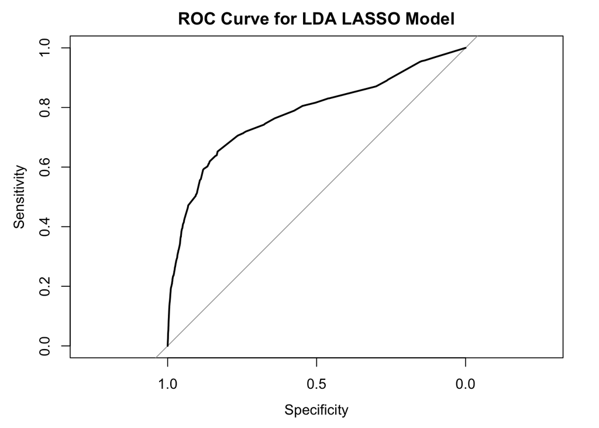

```r
plot(roc_obj, main = "ROC Curve for LDA LASSO Model")
```

```r
auc(roc_obj)
```

```
## Area under the curve: 0.7778
```

### 2.6 QDA

#### 2.6.1 Models

#### 2.6.2 CV

```r
results_qda_full     <- cv_qda_eval(full_df, target ~ ., model_name = "QDA_Full", k = 10)
results_qda_stepwise <- cv_qda_eval(full_df, stepwise_formula, model_name = "QDA_Stepwise", k = 10)
results_qda_lasso    <- cv_qda_eval(full_df, lasso_formula, model_name = "QDA_LASSO", k = 10)
```

#### 2.6.3 Evaluate

```r
qda_results <- rbind(results_qda_full, results_qda_stepwise, results_qda_lasso)

aggregate(cbind(Accuracy, F1, Sensitivity, Specificity) ~ Model + Optimized_For, data = qda_results, mean)
```

```
##          Model Optimized_For Accuracy      F1 Sensitivity Specificity
## 1     QDA_Full      Accuracy  0.87714 0.42612     0.40503     0.93710
## 2    QDA_LASSO      Accuracy  0.88095 0.42485     0.39052     0.94325
## 3 QDA_Stepwise      Accuracy  0.87720 0.42072     0.39619     0.93831
## 4     QDA_Full            F1  0.86826 0.44052     0.46017     0.92011
## 5    QDA_LASSO            F1  0.86718 0.44033     0.46444     0.91831
## 6 QDA_Stepwise            F1  0.86513 0.43668     0.46207     0.91617
```

```r
aggregate(Threshold ~ Model + Optimized_For, data = qda_results, mean)
```

```
##          Model Optimized_For Threshold
## 1     QDA_Full      Accuracy     0.973
## 2    QDA_LASSO      Accuracy     0.971
## 3 QDA_Stepwise      Accuracy     0.975
## 4     QDA_Full            F1     0.286
## 5    QDA_LASSO            F1     0.387
## 6 QDA_Stepwise            F1     0.356
```

#### 2.6.4 Best QDA

```r
print(qda_lasso_model)
```

```
## Call:
## qda(lasso_formula, data = full_df)
##
## Prior probabilities of groups:
##         0         1
## 0.8873445 0.1126555
##
## Group means:
##    cellular negative_emp   low_cpi  high_cci low_euribor university job_student
## 0 0.6122512    0.3732471 0.1958410 0.4123743   0.2781654  0.2894179  0.01631439
## 1 0.8332435    0.7685884 0.3922414 0.5660022   0.7206358  0.3617996  0.06115302
##   job_retired  month_sep  month_oct   month_dec   month_mar  p_failure
## 0  0.03543334 0.00844791 0.01084205 0.002667761 0.007250838 0.09990423
## 1  0.09671336 0.05711207 0.06627155 0.019935345 0.059267241 0.13011853
##    p_success
## 0 0.01347561
## 1 0.19585129
```

```r
probs_qda <- predict(qda_lasso_model)$posterior[, "1"]
pred_class_qda <- ifelse(probs_qda > 0.4, 1, 0)
table(Predicted = pred_class_qda, Actual = full_df$target)
```

```
##          Actual
## Predicted     0     1
##         0 27428  2213
##         1  1810  1499
```

```r
evaluate_threshold(probs_qda, full_df$target, threshold = 0.4)
```

```
## $Threshold
## [1] 0.4
##
## $Accuracy
## [1] 0.8779
##
## $F1
## [1] 0.427
##
## $Sensitivity
## [1] 0.4038
##
## $Specificity
## [1] 0.9381
```

#### 2.6.5 ROC Curve

```r
roc_qda <- roc(full_df$target, probs_qda)
```

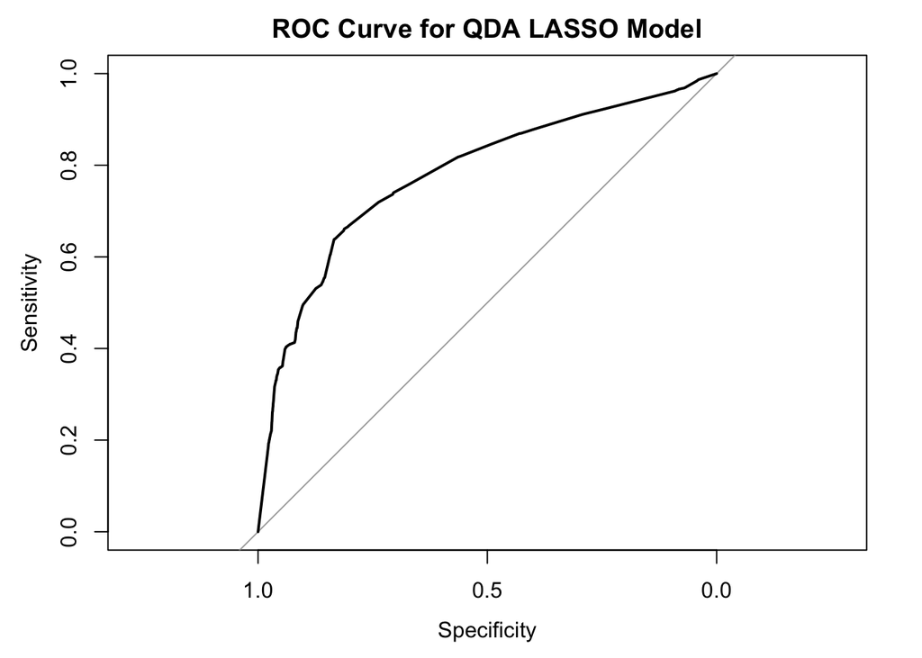

```r
plot(roc_qda, main = "ROC Curve for QDA LASSO Model")
```

```r
auc(roc_qda)
```

```
## Area under the curve: 0.78
```